# PISA (Programme for International Student Assessment) Analysis

## by Rafael Roldao L Dantas

## Preliminary Wrangling

> PISA is a survey of students' skills and knowledge as they approach the end of compulsory education. It is not a conventional school test. Rather than examining how well students have learned the school curriculum, it looks at how well prepared they are for life beyond school.

> Around 510,000 students in 65 economies took part in the PISA 2012 assessment of reading, mathematics and science representing about 28 million 15-year-olds globally. Of those economies, 44 took part in an assessment of creative problem solving and 18 in an assessment of financial literacy.

> Database source: https://s3.amazonaws.com/udacity-hosted-downloads/ud507/pisa2012.csv.zip.

### What is the structure of your dataset?

> The dataset includes 635 columns and 485,490 rows. The data include a sample of up to 33,806 students by country. In order to optimize computer processing, this analysis includes only OECD countries.

### What is/are the main feature(s) of interest in your dataset?

> The main interest of this analysis is evaluate the relative performance of students by country and have insights regarding what drive the average score of students.

### What features in the dataset do you think will help support your investigation into your feature(s) of interest?

> I expect the scores (math, reading, and science) will be the main outputs of the dataset. Therefore, I will make some analysis to see the relative position of countries according to PISA exam and try to get some insights that justify a better performance in the exam.

```python
# import all packages and set plots to be embedded inline
import numpy as np
import pandas as pd
import matplotlib.pyplot as plt
import seaborn as sb

%matplotlib inline
```

## DO NOT LOAD THIS DATAFRAME - MOVE TO UNIVARIATE EXPLORATION

```python
pisa_df = pd.read_csv('pisa2012.csv', sep=',', encoding='latin-1', error_bad_lines=False, index_col=0, dtype='unicode')
```

```python
pisa_df.head(10)
```

|  | CNT | SUBNATIO | STRATUM | OECD | NC | SCHOOLID | STIDSTD | ST01Q01 | ST02Q01 | ST03Q01 | ... | W_FSTR75 | W_FSTR76 | W_FSTR77 | W_FSTR78 | W_FSTR79 | W_FSTR80 | WVARSTRR | VAR_UNIT | SENWGT_STU | VER_STU |
| --- | --- | --- | --- | --- | --- | --- | --- | --- | --- | --- | --- | --- | --- | --- | --- | --- | --- | --- | --- | --- | --- |
| 1 | Albania | 0080000 | ALB0006 | Non-OECD | Albania | 0000001 | 00001 | 10 | 1 | 02 | ... | 13.7954 | 13.9235 | 13.1249 | 13.1249 | 4.3389 | 13.0829 | 19 | 1 | 0.2098 | 22NOV13 |
| 2 | Albania | 0080000 | ALB0006 | Non-OECD | Albania | 0000001 | 00002 | 10 | 1 | 02 | ... | 13.7954 | 13.9235 | 13.1249 | 13.1249 | 4.3389 | 13.0829 | 19 | 1 | 0.2098 | 22NOV13 |
| 3 | Albania | 0080000 | ALB0006 | Non-OECD | Albania | 0000001 | 00003 | 9 | 1 | 09 | ... | 12.7307 | 12.7307 | 12.7307 | 12.7307 | 4.2436 | 12.7307 | 19 | 1 | 0.1999 | 22NOV13 |
| 4 | Albania | 0080000 | ALB0006 | Non-OECD | Albania | 0000001 | 00004 | 9 | 1 | 08 | ... | 12.7307 | 12.7307 | 12.7307 | 12.7307 | 4.2436 | 12.7307 | 19 | 1 | 0.1999 | 22NOV13 |
| 5 | Albania | 0080000 | ALB0006 | Non-OECD | Albania | 0000001 | 00005 | 9 | 1 | 10 | ... | 12.7307 | 12.7307 | 12.7307 | 12.7307 | 4.2436 | 12.7307 | 19 | 1 | 0.1999 | 22NOV13 |
| 6 | Albania | 0080000 | ALB0006 | Non-OECD | Albania | 0000001 | 00006 | 9 | 1 | 09 | ... | 12.7307 | 12.7307 | 12.7307 | 12.7307 | 4.2436 | 12.7307 | 19 | 1 | 0.1999 | 22NOV13 |
| 7 | Albania | 0080000 | ALB0006 | Non-OECD | Albania | 0000001 | 00007 | 10 | 1 | 03 | ... | 13.7954 | 13.9235 | 13.1249 | 13.1249 | 4.3389 | 13.0829 | 19 | 1 | 0.2098 | 22NOV13 |
| 8 | Albania | 0080000 | ALB0006 | Non-OECD | Albania | 0000001 | 00008 | 10 | 1 | 06 | ... | 14.4599 | 14.6374 | 15.8728 | 15.8728 | 5.2248 | 15.2579 | 19 | 1 | 0.2322 | 22NOV13 |
| 9 | Albania | 0080000 | ALB0006 | Non-OECD | Albania | 0000001 | 00009 | 9 | 1 | 10 | ... | 12.7307 | 12.7307 | 12.7307 | 12.7307 | 4.2436 | 12.7307 | 19 | 1 | 0.1999 | 22NOV13 |
| 10 | Albania | 0080000 | ALB0005 | Non-OECD | Albania | 0000002 | 00010 | 10 | 1 | 08 | ... | 3.3844 | 10.1533 | 3.3844 | 10.1533 | 10.1533 | 10.1533 | 74 | 2 | 0.1594 | 22NOV13 |

10 rows × 635 columns

```python
pisa_df.info()
```

```
<class 'pandas.core.frame.DataFrame'>
Int64Index: 485490 entries, 1 to 485490
Columns: 635 entries, CNT to VER_STU
dtypes: object(635)
memory usage: 2.3+ GB
```

```python
list(pisa_df['OECD'].value_counts().index)
```

```
['OECD', 'Non-OECD']
```

```python
pisa_oecd = pisa_df[pisa_df['OECD'] == 'OECD']
pisa_oecd.info()
```

```
<class 'pandas.core.frame.DataFrame'>
Int64Index: 295416 entries, 22152 to 480531
Columns: 635 entries, CNT to VER_STU
dtypes: object(635)
memory usage: 1.4+ GB
```

```python
pisa_oecd.to_csv('pisa_oecd_2012.csv')
```

```python
pisa_oecd.info()
```

```
<class 'pandas.core.frame.DataFrame'>
Int64Index: 295416 entries, 22152 to 480531
Columns: 635 entries, CNT to VER_STU
dtypes: object(635)
memory usage: 1.4+ GB
```

## Univariate Exploration

### Discuss the distribution(s) of your variable(s) of interest. Were there any unusual points? Did you need to perform any transformations?

> Most of the dataframe is in 'str' format. Therefore, for numeric variables, I had to transform in 'int' or 'float'.

### Of the features you investigated, were there any unusual distributions? Did you perform any operations on the data to tidy, adjust, or change the form of the data? If so, why did you do this?

> This kind of transformation was not necessary.

```python
pisa_oecd_original = pd.read_csv('pisa_oecd_2012.csv', sep=',', encoding='latin-1', error_bad_lines=False, index_col=0, dtype='unicode')
```

```python
pisa_oecd = pisa_oecd_original.copy()
pisa_oecd.head()
```

|  | CNT | SUBNATIO | STRATUM | OECD | NC | SCHOOLID | STIDSTD | ST01Q01 | ST02Q01 | ST03Q01 | ... | W_FSTR75 | W_FSTR76 | W_FSTR77 | W_FSTR78 | W_FSTR79 | W_FSTR80 | WVARSTRR | VAR_UNIT | SENWGT_STU | VER_STU |
| --- | --- | --- | --- | --- | --- | --- | --- | --- | --- | --- | --- | --- | --- | --- | --- | --- | --- | --- | --- | --- | --- |
| 22152 | Australia | 0360000 | AUS0309 | OECD | Australia | 0000001 | 00001 | 10 | 1 | 11 | ... | 21.3359 | 21.3359 | 45.7184 | 45.7184 | 21.3359 | 45.7184 | 76 | 3 | 0.1332 | 22NOV13 |
| 22153 | Australia | 0360000 | AUS0309 | OECD | Australia | 0000001 | 00002 | 10 | 2 | 12 | ... | 21.3359 | 21.3359 | 45.7184 | 45.7184 | 21.3359 | 45.7184 | 76 | 3 | 0.1332 | 22NOV13 |
| 22154 | Australia | 0360000 | AUS0309 | OECD | Australia | 0000001 | 00003 | 10 | 1 | 07 | ... | 21.3359 | 21.3359 | 45.7184 | 45.7184 | 21.3359 | 45.7184 | 76 | 3 | 0.1332 | 22NOV13 |
| 22155 | Australia | 0360000 | AUS0309 | OECD | Australia | 0000001 | 00004 | 10 | 1 | 09 | ... | 21.1106 | 21.1106 | 52.0104 | 52.0104 | 21.1106 | 52.0104 | 76 | 3 | 0.1405 | 22NOV13 |
| 22156 | Australia | 0360000 | AUS0309 | OECD | Australia | 0000001 | 00005 | 10 | 1 | 06 | ... | 21.1106 | 21.1106 | 52.0104 | 52.0104 | 21.1106 | 52.0104 | 76 | 3 | 0.1405 | 22NOV13 |

5 rows × 635 columns

```python
list(pisa_oecd['CNT'].value_counts().index)
```

```
['Mexico',
 'Italy',
 'Spain',
 'Canada',
 'Australia',
 'United Kingdom',
 'Switzerland',
 'Finland',
 'Belgium',
 'Denmark',
 'Chile',
 'Japan',
 'Slovenia',
 'Portugal',
 'Czech Republic',
 'Luxembourg',
 'Greece',
 'Israel',
 'Korea',
 'Ireland',
 'Germany',
 'United States of America',
 'Turkey',
 'Hungary',
 'Estonia',
 'Austria',
 'Sweden',
 'Norway',
 'Slovak Republic',
 'France',
 'Poland',
 'Netherlands',
 'New Zealand',
 'Iceland']
```

```python
list(pisa_oecd['ST01Q01'].value_counts().index)
```

```
['10', '9', '11', '8', '12', '7', '96', '13']
```

```python
pisa_oecd.STIDSTD.nunique(), pisa_oecd.STIDSTD.max()
```

```
(33806, '33806')
```

### Math Analysis

```python
type(pisa_oecd.PV1MATH.iloc[0])
```

```
str
```

> Comments: Considering the math scores are in 'str' format, I should transform it into 'float' format to make numeric analysis.

```python
pisa_oecd['PV1MATH'] = pisa_oecd['PV1MATH'].astype(float)
pisa_oecd['PV2MATH'] = pisa_oecd['PV2MATH'].astype(float)
pisa_oecd['PV3MATH'] = pisa_oecd['PV3MATH'].astype(float)
pisa_oecd['PV4MATH'] = pisa_oecd['PV4MATH'].astype(float)
pisa_oecd['PV5MATH'] = pisa_oecd['PV5MATH'].astype(float)
```

```python
pisa_oecd['PV1MATH'].describe()
```

```
count    295416.000000
mean        488.347772
std          95.422257
min          59.674400
25%         420.945600
50%         487.466900
75%         554.845000
max         896.798600
Name: PV1MATH, dtype: float64
```

> Comments: I will create a subset including the nominal variables and math scores.

```python
df_math = pisa_oecd.iloc[:, np.r_[:5, 500:505]]
df_math = df_math.groupby('CNT').mean()
df_math = df_math.reset_index()
df_math.head()
```

|  | CNT | PV1MATH | PV2MATH | PV3MATH | PV4MATH | PV5MATH |
| --- | --- | --- | --- | --- | --- | --- |
| 0 | Australia | 492.842855 | 493.335736 | 493.353218 | 493.636585 | 493.176301 |
| 1 | Austria | 507.711753 | 507.529917 | 507.837725 | 507.763517 | 508.051011 |
| 2 | Belgium | 519.868902 | 519.855583 | 519.374375 | 519.873523 | 519.369665 |
| 3 | Canada | 509.328982 | 509.618661 | 509.099141 | 509.423964 | 509.617685 |
| 4 | Chile | 444.419644 | 444.728561 | 444.243997 | 445.436035 | 444.633352 |

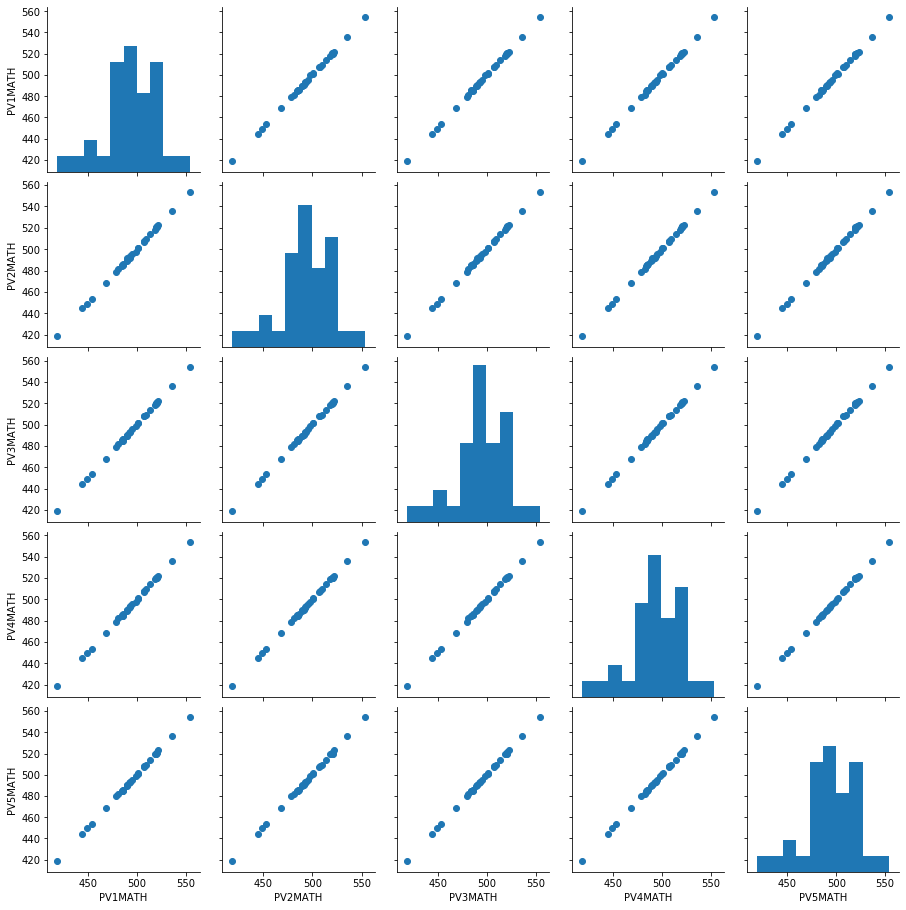

```python
g = sb.PairGrid(data=df_math, vars=['PV1MATH', 'PV2MATH', 'PV3MATH', 'PV4MATH', 'PV5MATH'])
g.map_diag(plt.hist)
g.map_offdiag(plt.scatter);
```

> Comments: I made the correlation charts above because the database includes 5 different scores for Math. However, given they are almost perfectly positive correlated, I will use only the first score ('PV1MATH') for my analysis.

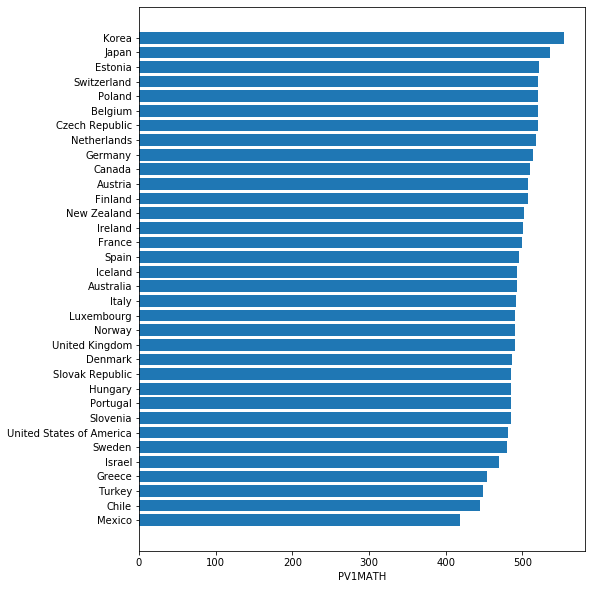

```python
df_math_chart = df_math.sort_values('PV1MATH')

plt.figure(figsize=[8,10])
plt.barh('CNT', 'PV1MATH', data=df_math_chart)
plt.xlabel('PV1MATH');
```

> Comments: Raking of countries by Math score

### Reading Analysis

```python
pisa_oecd.PV1READ.iloc[0]
```

```
'582.3127'
```

```python
type(pisa_oecd.PV1READ.iloc[0])
```

```
str
```

> Comments: Considering the reading scores are in 'str' format, I should transform it into 'float' format to make numeric analysis.

```python
pisa_oecd['PV1READ'] = pisa_oecd['PV1READ'].astype(float)
pisa_oecd['PV2READ'] = pisa_oecd['PV2READ'].astype(float)
pisa_oecd['PV3READ'] = pisa_oecd['PV3READ'].astype(float)
pisa_oecd['PV4READ'] = pisa_oecd['PV4READ'].astype(float)
pisa_oecd['PV5READ'] = pisa_oecd['PV5READ'].astype(float)
```

> Comments: I will create a subset including the nominal variables and reading scores.

```python
df_read = pisa_oecd.iloc[:, np.r_[:5, 540:545]]
df_read = df_read.groupby('CNT').mean()
df_read = df_read.reset_index()
df_read.head()
```

|  | CNT | PV1READ | PV2READ | PV3READ | PV4READ | PV5READ |
| --- | --- | --- | --- | --- | --- | --- |
| 0 | Australia | 500.845303 | 501.012221 | 501.296108 | 501.186905 | 500.944116 |
| 1 | Austria | 490.918021 | 491.921403 | 491.204811 | 491.517774 | 491.865745 |
| 2 | Belgium | 512.319008 | 512.054427 | 512.264622 | 512.687829 | 512.082752 |
| 3 | Canada | 511.235906 | 511.293748 | 510.857946 | 510.622800 | 510.778339 |
| 4 | Chile | 459.999572 | 460.618594 | 459.947040 | 460.843767 | 460.173572 |

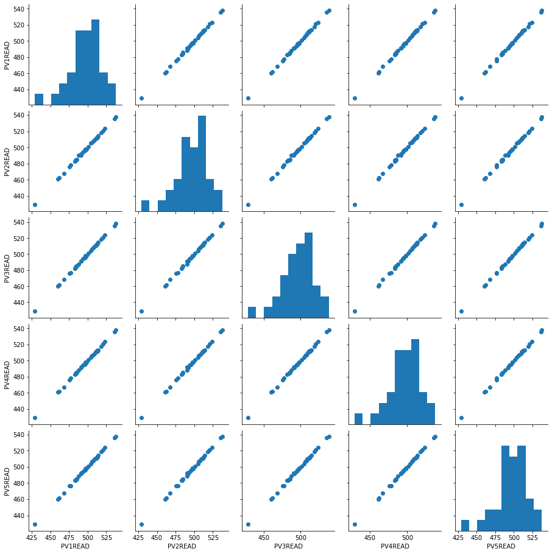

```python
r = sb.PairGrid(data=df_read, vars=['PV1READ', 'PV2READ', 'PV3READ', 'PV4READ', 'PV5READ'])
r.map_diag(plt.hist)
r.map_offdiag(plt.scatter);
```

> Comments: Similarly with math scores, there is a high positive correlation among all reading scores. Therefore I will use only the first score ('PV1READ') for my analysis.

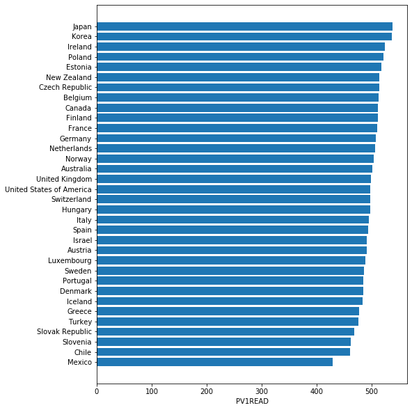

```python
df_read_chart = df_read.sort_values('PV1READ')

plt.figure(figsize=[8,10])
plt.barh('CNT', 'PV1READ', data=df_read_chart)
plt.xlabel('PV1READ');
```

> Comments: Raking of countries by Reading score.

### Science Analysis

```python
pisa_oecd.PV1SCIE.iloc[0]
```

```
'583.495'
```

```python
type(pisa_oecd.PV1SCIE.iloc[0])
```

```
str
```

> Comments: Considering the science scores are in 'str' format, I should transform it into 'float' format to make numeric analysis.

```python
pisa_oecd['PV1SCIE'] = pisa_oecd['PV1SCIE'].astype(float)
pisa_oecd['PV2SCIE'] = pisa_oecd['PV2SCIE'].astype(float)
pisa_oecd['PV3SCIE'] = pisa_oecd['PV3SCIE'].astype(float)
pisa_oecd['PV4SCIE'] = pisa_oecd['PV4SCIE'].astype(float)
pisa_oecd['PV5SCIE'] = pisa_oecd['PV5SCIE'].astype(float)
```

> Comments: I will create a subset including the nominal variables and science scores.

```python
df_scie = pisa_oecd.iloc[:, np.r_[:5, 545:550]]
df_scie = df_scie.groupby('CNT').mean()
df_scie = df_scie.reset_index()
df_scie.head()
```

|  | CNT | PV1SCIE | PV2SCIE | PV3SCIE | PV4SCIE | PV5SCIE |
| --- | --- | --- | --- | --- | --- | --- |
| 0 | Australia | 511.250599 | 511.427811 | 512.042515 | 511.775281 | 511.694853 |
| 1 | Austria | 507.213082 | 508.041635 | 508.020063 | 508.495425 | 508.413846 |
| 2 | Belgium | 510.475079 | 510.124080 | 510.177555 | 510.588426 | 510.147835 |
| 3 | Canada | 514.712929 | 514.524908 | 514.382983 | 514.351127 | 514.311219 |
| 4 | Chile | 464.572824 | 465.028051 | 464.358200 | 465.060557 | 464.599346 |

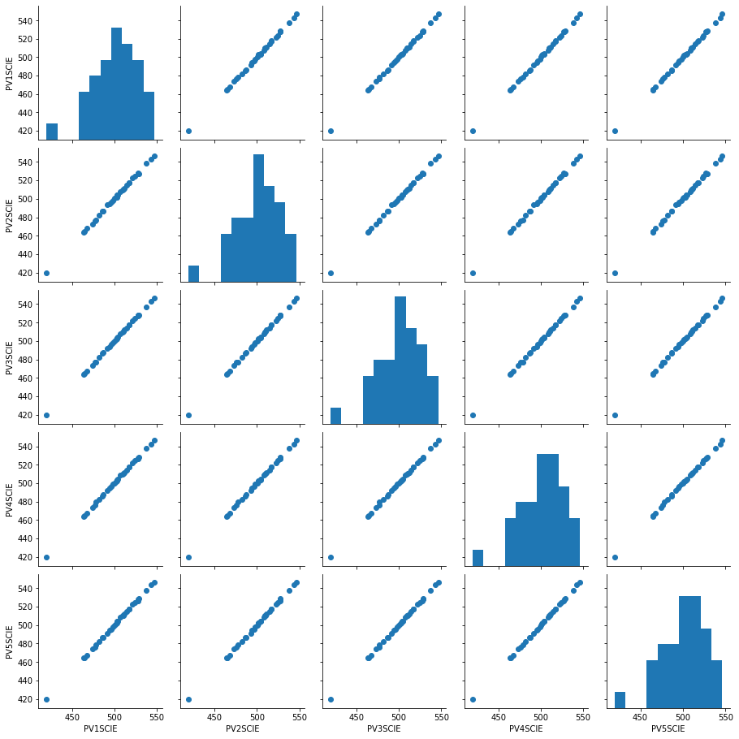

```python
s = sb.PairGrid(data=df_scie, vars=['PV1SCIE', 'PV2SCIE', 'PV3SCIE', 'PV4SCIE', 'PV5SCIE'])
s.map_diag(plt.hist)
s.map_offdiag(plt.scatter);
```

> Comments: Similarly with math and reading scores, there is a high positive correlation among all science scores. Therefore I will use only the first score ('PV1SCIE') for my analysis.

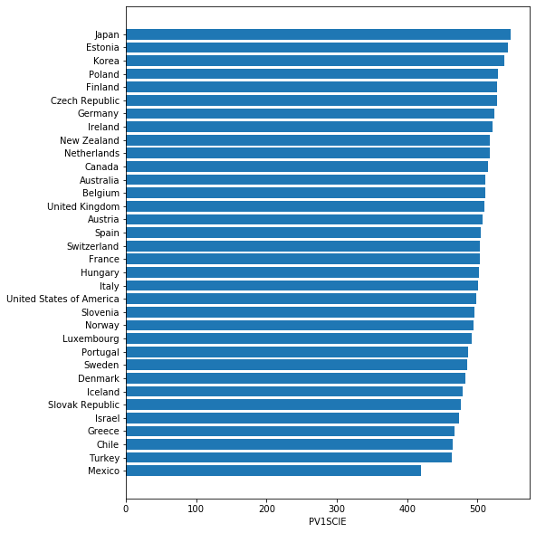

```python
df_scie_chart = df_scie.sort_values('PV1SCIE')

plt.figure(figsize=[8,10])
plt.barh('CNT', 'PV1SCIE', data=df_scie_chart)
plt.xlabel('PV1SCIE');
```

> Comments: I will create a subset including countries and math, reading, and science scores.

```python
df_scores = pisa_oecd.iloc[:, np.r_[:5, 500, 540, 545]]
df_scores = df_scores.groupby('CNT').mean()
df_scores = df_scores.reset_index()
df_scores.head()
```

|  | CNT | PV1MATH | PV1READ | PV1SCIE |
| --- | --- | --- | --- | --- |
| 0 | Australia | 492.842855 | 500.845303 | 511.250599 |
| 1 | Austria | 507.711753 | 490.918021 | 507.213082 |
| 2 | Belgium | 519.868902 | 512.319008 | 510.475079 |
| 3 | Canada | 509.328982 | 511.235906 | 514.712929 |
| 4 | Chile | 444.419644 | 459.999572 | 464.572824 |

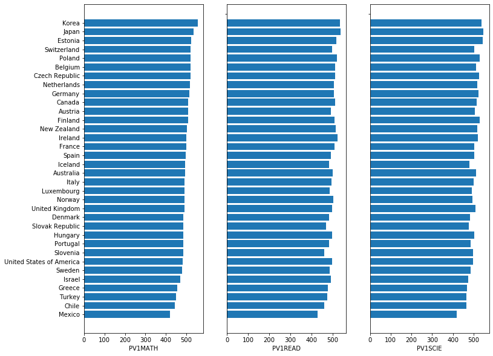

```python
df_scores_chart = df_scores.sort_values('PV1MATH')

plt.figure(figsize=[12,10])

plt.subplot(1, 3, 1)
plt.barh('CNT', 'PV1MATH', data=df_scores_chart)
plt.xlabel('PV1MATH');

plt.subplot(1, 3, 2)
plt.barh('CNT', 'PV1READ', data=df_scores_chart)
plt.xlabel('PV1READ')
plt.yticks("");

plt.subplot(1, 3, 3)
plt.barh('CNT', 'PV1SCIE', data=df_scores_chart)
plt.xlabel('PV1SCIE')
plt.yticks("");
```

> Comments: In order to facilitate the comparison between math, reading, and science scores by country, I ploted the charts side by side sorted by math scores.

## Bivariate Exploration

### Talk about some of the relationships you observed in this part of the investigation. How did the feature(s) of interest vary with other features in the dataset?

> In this session, I will analyze the correlation between math and reading scores. In addition, I will check the effect of math lessons with math scores.

### Did you observe any interesting relationships between the other features (not the main feature(s) of interest)?

> Interesting insides below.

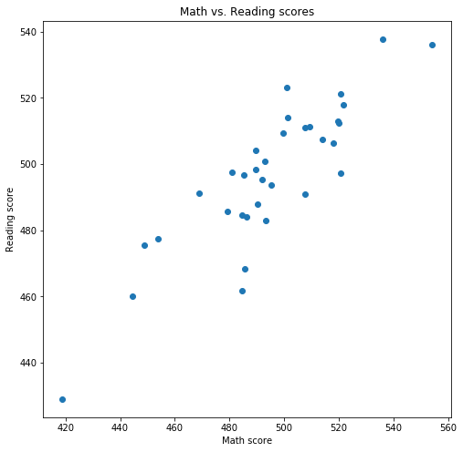

```python
plt.figure(figsize=[8,8])
plt.scatter(data=df_scores_chart, x='PV1MATH', y='PV1READ')
plt.xlabel('Math score')
plt.ylabel('Reading score')
plt.title('Math vs. Reading scores');
```

> Comments: As expected, there is a high positive correlation between math and reading scores. So, a country with a high math score tend to have high reading score.

> Comments: I will check the possible answers for 'math lessons - draw graph' and 'math lessons - calculation with numbers'.

```python
list(pisa_oecd['IC11Q01'].value_counts().index)
```

```
['No',
 'Yes, students did this',
 'Yes, but only the teacher demonstrated this ']
```

```python
list(pisa_oecd['IC11Q02'].value_counts().index)
```

```
['No',
 'Yes, students did this',
 'Yes, but only the teacher demonstrated this ']
```

> Comments: I will create a subset including math lessons variables and math score.

```python
df_math_lessons = pisa_oecd.iloc[:, np.r_[332:339, 500]]
df_math_lessons = df_math_lessons.reset_index()
df_math_lessons.head()
```

|  | index | IC11Q01 | IC11Q02 | IC11Q03 | IC11Q04 | IC11Q05 | IC11Q06 | IC11Q07 | PV1MATH |
| --- | --- | --- | --- | --- | --- | --- | --- | --- | --- |
| 0 | 22152 | No | No | No | No | No | No | No | 561.5439 |
| 1 | 22153 | Yes, but only the teacher demonstrated this | Yes, but only the teacher demonstrated this | No | Yes, but only the teacher demonstrated this | Yes, students did this | Yes, but only the teacher demonstrated this | Yes, but only the teacher demonstrated this | 564.8154 |
| 2 | 22154 | No | No | No | Yes, students did this | No | No | No | 507.3298 |
| 3 | 22155 | No | No | No | No | No | No | No | 601.7370 |
| 4 | 22156 | No | No | No | No | No | No | No | 520.1823 |

> Comments: I will categorize math lessons variables.

```python
list_of_vars = ["IC11Q0{}".format(i) for i in range(1,7)]

answer_order = ['No', 'Yes, but only the teacher demonstrated this ', 'Yes, students did this']

for var in list_of_vars:
    df_math_lessons[var] = pd.Categorical(df_math_lessons[var],
                                    categories=answer_order,
                                    ordered = True)
```

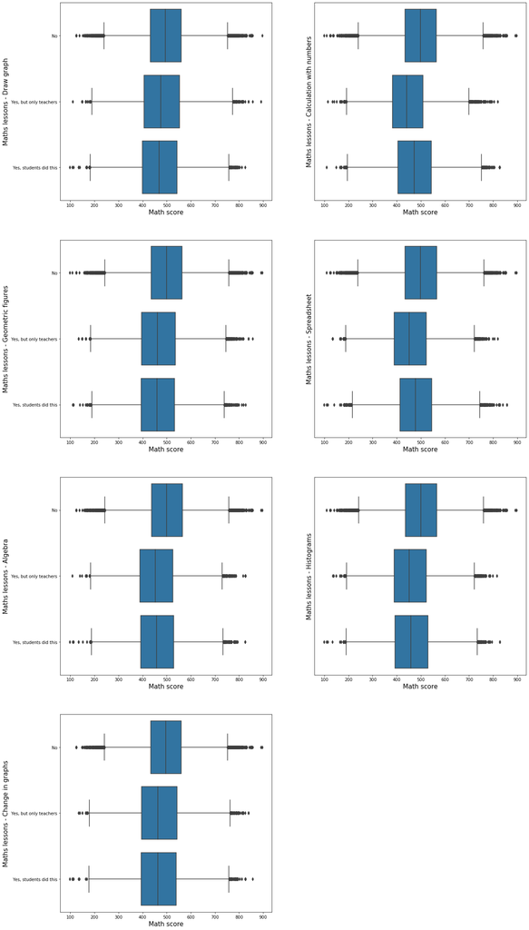

```python
plt.figure(figsize=[20,40])
base_color = sb.color_palette()[0]

plt.subplot(4, 2, 1)
sb.boxplot(data=df_math_lessons, y='IC11Q01', x='PV1MATH', color=base_color)
plt.ylabel('Maths lessons - Draw graph', fontsize=15)
plt.yticks([0, 1, 2], ['No', 'Yes, but only teachers', 'Yes, students did this'])
plt.xlabel('Math score', fontsize=15);

plt.subplot(4, 2, 2)
sb.boxplot(data=df_math_lessons, y='IC11Q02', x='PV1MATH', color=base_color)
plt.ylabel('Maths lessons - Calculation with numbers', fontsize=15)
plt.yticks([], [])
plt.xlabel('Math score', fontsize=15);

plt.subplot(4, 2, 3)
sb.boxplot(data=df_math_lessons, y='IC11Q03', x='PV1MATH', color=base_color)
plt.ylabel('Maths lessons - Geometric figures', fontsize=15)
plt.yticks([0, 1, 2], ['No', 'Yes, but only teachers', 'Yes, students did this'])
plt.xlabel('Math score', fontsize=15);

plt.subplot(4, 2, 4)
sb.boxplot(data=df_math_lessons, y='IC11Q04', x='PV1MATH', color=base_color)
plt.ylabel('Maths lessons - Spreadsheet', fontsize=15)
plt.yticks([], [])
plt.xlabel('Math score', fontsize=15);

plt.subplot(4, 2, 5)
sb.boxplot(data=df_math_lessons, y='IC11Q05', x='PV1MATH', color=base_color)
plt.ylabel('Maths lessons - Algebra', fontsize=15)
plt.yticks([0, 1, 2], ['No', 'Yes, but only teachers', 'Yes, students did this'])
plt.xlabel('Math score', fontsize=15);

plt.subplot(4, 2, 6)
sb.boxplot(data=df_math_lessons, y='IC11Q06', x='PV1MATH', color=base_color)
plt.ylabel('Maths lessons - Histograms', fontsize=15)
plt.yticks([], [])
plt.xlabel('Math score', fontsize=15);

plt.subplot(4, 2, 7)
sb.boxplot(data=df_math_lessons, y='IC11Q07', x='PV1MATH', color=base_color)
plt.ylabel('Maths lessons - Change in graphs', fontsize=15)
plt.yticks([0, 1, 2], ['No', 'Yes, but only teachers', 'Yes, students did this'])
plt.xlabel('Math score', fontsize=15);
```

> Comments: Are the students that make math lessons have a better performance than students that don't. Despite unintuitive, the database indicates the oposite for most of math subareas.

## Multivariate Exploration

### Talk about some of the relationships you observed in this part of the investigation. Were there features that strengthened each other in terms of looking at your feature(s) of interest?

> In this section I will analyze the performance of students in math and reading areas by country. In addition, I will analize the relationship among math, reading and science scores.

### Were there any interesting or surprising interactions between features?

> More details below.

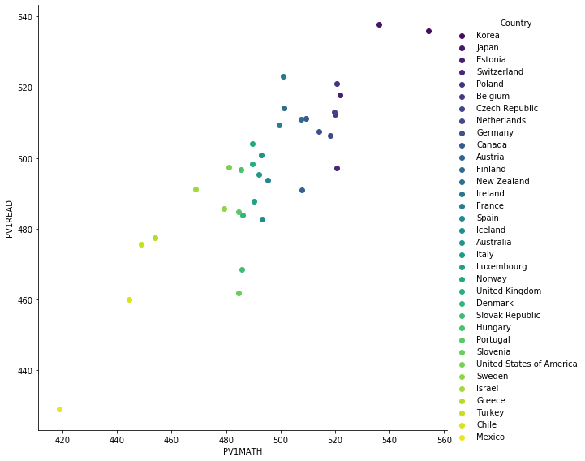

```python
df_scores_chart1 = df_scores_chart.sort_values('PV1MATH', ascending=False)
ss = sb.FacetGrid(data=df_scores_chart1, hue='CNT', height=8, palette='viridis');
ss.map(plt.scatter, 'PV1MATH', 'PV1READ')
ss.add_legend(title='Country');
```

> Comments: Ranking of countries by math score including reading score.

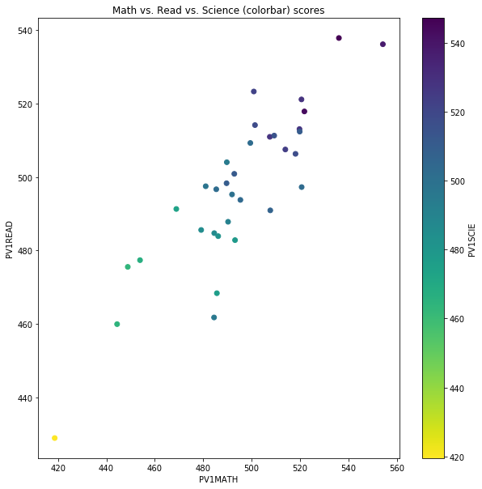

```python
plt.figure(figsize=[10,10])

plt.scatter(data=df_scores_chart, x='PV1MATH', y='PV1READ', c='PV1SCIE', cmap='viridis_r')
plt.colorbar(label='PV1SCIE');
plt.xlabel('PV1MATH')
plt.ylabel('PV1READ')
plt.title('Math vs. Read vs. Science (colorbar) scores');
```

> Comments: There is a high positive correlation among math, reading, and science scores, as expected.